# Introduction to proteomics data analysis

Lieven Clement

11 October 2019

# 1 Background

A study on the facultative pathogen Francisella tularensis was conceived by Ramond et al. (2015) [12]. F. tularensis enters the cells of its host by phagocytosis. The authors showed that F. tularensis is arginine deficient and imports arginine from the host cell via an arginine transporter, ArgP, in order to efficiently escape from the phagosome and reach the cytosolic compartment, where it can actively multiply. In their study, they compared the proteome of wild type F. tularensis (WT) to ArgP-gene deleted F. tularensis (knock-out, D8). For this exercise, we use a subset of the F. tularensis dataset where bacterial cultures were grown in biological triplicate and each sample was run on a nanoRSLC-Q Exactive PLUS instrument. The data were searched with MaxQuant version 1.4.1.2. The data can be found on https://github.com/statOmics/SGA2019/tree/data.

# 2 Data

We first import the peptides.txt file. This is the file that contains your peptide-level intensities. For a MaxQuant search [6], this peptides.txt file can be found by default in the “path_to_raw_files/combined/txt/” folder from the MaxQuant output, with “path_to_raw_files” the folder where raw files were saved. In this tutorial, we will use a MaxQuant peptides file from MaxQuant that can be found on the pdaData repository. We will use the MSnbase package to import the data.

We generate the object peptideFile with the path to the peptides.txt file. In this file we will fetch the data from the github repository linked to the SGA2019 course: https://statomics.github.io/SGA2019. You can also replace the peptideFile with a string that points to the path of a file on your local hard drive. With the grepEcols function we find the columns that are containing the expression data of the peptides in the peptides.txt file.

```r
library(MSqRob)
library(MSnbase)
library(tidyverse)
library(limma)
peptidesFile <- "~/Downloads/SGA2019-data/quantification/francisella/peptides.txt"
proteinGroupsFile <-"~/Downloads/SGA2019-data/quantification/francisella/proteinGroups.txt"
ecols<-grepEcols(peptidesFile, "Intensity ", split = "\t")
```

Next we import the peptide intensities

```r
pepData<-readMSnSet2(peptidesFile,ecol=ecols,fnames="Sequence",sep="\t")
pepData
```

```
## MSnSet (storageMode: lockedEnvironment)
## assayData: 10693 features, 6 samples
##   element names: exprs
## protocolData: none
## phenoData: none
## featureData
##   featureNames: AAAEELDTR AAAGFVITASHNK ... YYYIADYEITFLYAYQALNYLK
##     (10693 total)
##   fvarLabels: Sequence Amino.acid.before ... Oxidation..M..site.IDs
##     (56 total)
##   fvarMetadata: labelDescription
## experimentData: use 'experimentData(object)'
## Annotation:
## - - - Processing information - - -
##  MSnbase version: 2.10.1
```

The pepData object is an MSnSet, a container for the data, features information and experimental annotation. They can be accessed using the accessor functions ‘exprs’ (matrix of intensities, features in rows, samples in columns), ‘fData’ (properties for each feature, peptide or protein, on the rows) and ‘pData’ (properties for the samples on the columns).

We will make use from data wrangling functionalities from the tidyverse package. The %>% operator allows us to pipe the output of one function to the next function.

```r
head(exprs(pepData))
```

```
##                         Intensity.1WT_20_2h_n3_3 Intensity.1WT_20_2h_n4_3
## AAAEELDTR                                9290400                 98059000
## AAAGFVITASHNK                                  0                        0
## AAANEYELALAYSIEEVAPDLHK                 30436000                 20687000
## AAANNPQLEAFK                           393930000                360270000
## AAASAGLVDEK                            241890000                        0
## AAASLDLYSYPK                            31448000                 28657000
##                         Intensity.1WT_20_2h_n5_3 Intensity.3D8_20_2h_n3_3
## AAAEELDTR                                      0                        0
## AAAGFVITASHNK                           13841000                        0
## AAANEYELALAYSIEEVAPDLHK                  7009100                  7859200
## AAANNPQLEAFK                           271440000                282500000
## AAASAGLVDEK                            143340000                168620000
## AAASLDLYSYPK                                   0                        0
##                         Intensity.3D8_20_2h_n4_3 Intensity.3D8_20_2h_n5_3
## AAAEELDTR                                      0                        0
## AAAGFVITASHNK                            8723500                        0
## AAANEYELALAYSIEEVAPDLHK                  4470500                  3422300
## AAANNPQLEAFK                           219700000                170400000
## AAASAGLVDEK                                    0                100090000
## AAASLDLYSYPK                                   0                        0
```

```r
pepData %>% exprs %>% head
```

```
##                         Intensity.1WT_20_2h_n3_3 Intensity.1WT_20_2h_n4_3
## AAAEELDTR                                9290400                 98059000
## AAAGFVITASHNK                                  0                        0
## AAANEYELALAYSIEEVAPDLHK                 30436000                 20687000
## AAANNPQLEAFK                           393930000                360270000
## AAASAGLVDEK                            241890000                        0
## AAASLDLYSYPK                            31448000                 28657000
##                         Intensity.1WT_20_2h_n5_3 Intensity.3D8_20_2h_n3_3
## AAAEELDTR                                      0                        0
## AAAGFVITASHNK                           13841000                        0
## AAANEYELALAYSIEEVAPDLHK                  7009100                  7859200
## AAANNPQLEAFK                           271440000                282500000
## AAASAGLVDEK                            143340000                168620000
## AAASLDLYSYPK                                   0                        0
##                         Intensity.3D8_20_2h_n4_3 Intensity.3D8_20_2h_n5_3
## AAAEELDTR                                      0                        0
## AAAGFVITASHNK                            8723500                        0
## AAANEYELALAYSIEEVAPDLHK                  4470500                  3422300
## AAANNPQLEAFK                           219700000                170400000
## AAASAGLVDEK                                    0                100090000
## AAASLDLYSYPK                                   0                        0
```

```r
pepData %>% sampleNames
```

```
## [1] "Intensity.1WT_20_2h_n3_3" "Intensity.1WT_20_2h_n4_3"
## [3] "Intensity.1WT_20_2h_n5_3" "Intensity.3D8_20_2h_n3_3"
## [5] "Intensity.3D8_20_2h_n4_3" "Intensity.3D8_20_2h_n5_3"
```

```r
sampleNames(pepData) <- pepData %>% sampleNames %>% str_replace(., pattern="Intensity.", replacement="")
```

Next we will add information on the proteins to the feature data. The feature data of the object pepData contains information for each peptide in the experiment. This info on the proteins can be found in the proteingroups.txt file of maxquant. The peptides.txt file contains many data on each feature (peptide). We will only retain specified columns Protein, Sequence, Reverse and Contaminant, indicating the protein, peptide sequence, if the peptide is a decoy and if it is a contaminant, respectively.

In older and more recent versions of maxquant the names of the fields might vary. We can therefore explore the names we want to select with the shiny app that can be launched from the selectFeatureData from the MSnbase package, i.e. by running the function without an fcol argument that specifies the columns you would like to select.

The code can be found below, but is not executed by this Rmd script (note, that the flag eval=FALSE has been used as option for the R chunk).

```r
pepData<-selectFeatureData(pepData)
```

If we know the columns, we can specify them as a vector in the fcol slot.

```r
pepData<-selectFeatureData(pepData,fcol=c("Proteins","Contaminant","Reverse","Sequence"))
```

Calculate how many non zero intensities we have per peptide. This will be useful for filtering.

```r
fData(pepData)$nNonZero<- rowSums(exprs(pepData) > 0)
```

Peptides with zero intensities are missing peptides and should be represent with a `NA` value instead of `0`.

```r
exprs(pepData)[exprs(pepData)==0]<-NA
```

```r
pData(pepData)$genotype <- pepData %>% sampleNames %>% substr(2,3) %>% as.factor
```

## 2.1 Data exploration

We can inspect the missingness in our data with the `plotNA()` function provided with `MSnbase`. 49% of all peptide intensities are missing and for some peptides we don’t even measure a signal in any sample. The missingness is similar across samples. Note, that we plot the peptide data, so the label protein in the plot refers to peptides.

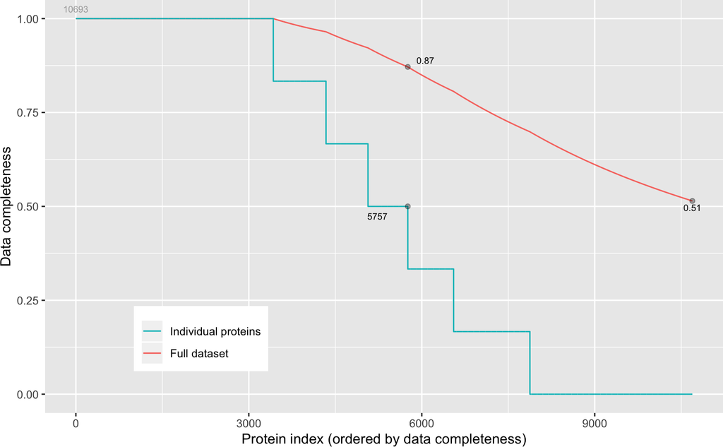

```r
plotNA(pepData)
```

When we look at density plots of the intensities, we see that most intensities are low and that there is a long tail to the right. It is more useful to explore the data upon log transformation.

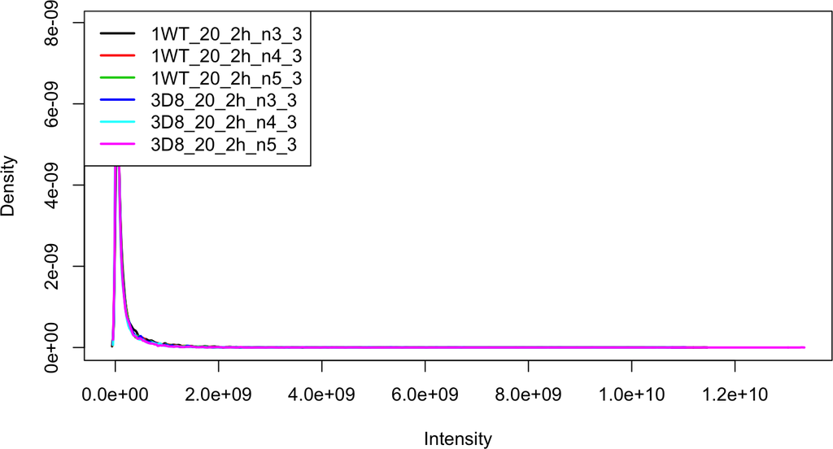

```r
plotDensities(exprs(pepData))
```

```r
nrow(pepData)
```

```
## [1] 10693
```

There are 10693 peptides before preprocessing.

# 3 Preprocessing

We will log transform, normalize, filter and summarize the data.

## 3.1 Log transform the data

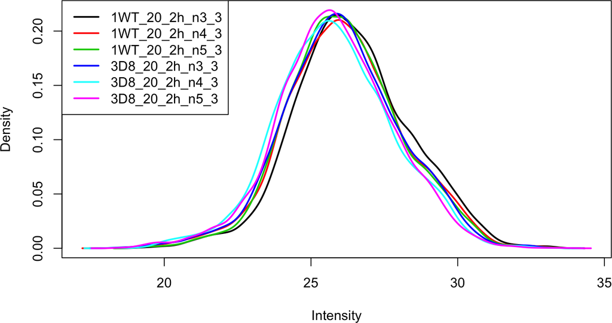

```r
pepData <- log(pepData, base = 2)
plotDensities(exprs(pepData))
```

When we look at the densities we see small shifts in location and shape of the density distributions. So normalisation will be required. But, we will first perform filtering.

## 3.2 Filtering

### 3.2.1 Handling overlapping protein groups

In our approach a peptide can map to multiple proteins, as long as there is none of these proteins present in a smaller subgroup.

```r
pepData<-pepData[fData(pepData)$Proteins %in% smallestUniqueGroups(fData(pepData)$Proteins),]
```

### 3.2.2 Remove reverse sequences (decoys) and contaminants

We now remove the contaminants, peptides that map to decoy sequences and proteins, which were only identified by peptides with modifications.

```r
pepData <- pepData[fData(pepData)$Reverse!="+",]
pepData <- pepData[fData(pepData)$Contaminant!="+",]
```

### 3.2.3 Remove peptides of proteins that were only identified with modified peptides

```r
proteinGroups<-read.table(proteinGroupsFile, sep = "\t", header = TRUE, quote = "", comment.char = "")
only_site <- proteinGroups$Only.identified.by.site
only_site[is.na(only_site)] <- ""
proteinsOnlyIdentifiedWithPTMs <- proteinGroups$Protein.IDs[only_site=="+"]
pepData<-pepData[!(fData(pepData)$Proteins %in% proteinsOnlyIdentifiedWithPTMs),]
```

We will now remove the proteinGroups object from the R session to free memory.

```r
rm(proteinGroups,only_site)
gc()
```

```
##           used  (Mb) gc trigger  (Mb) limit (Mb) max used  (Mb)
## Ncells 4098055 218.9    8009862 427.8         NA  5360301 286.3
## Vcells 7014865  53.6   14859874 113.4      16384 12315752  94.0
```

### 3.2.4 Drop peptides that were only identified in one sample

We want to keep peptide that were at least observed twice.

```r
pepData<-pepData[fData(pepData)$nNonZero>=2,]
nrow(pepData)
```

```
## [1] 6525
```

We keep 6525 peptides upon filtering.

## 3.3 Quantile normalize the data

```r
pepData <- normalise(pepData, "quantiles")
```

## 3.4 Explore quantile normalized data

Upon normalisation the density curves for all samples coincide.

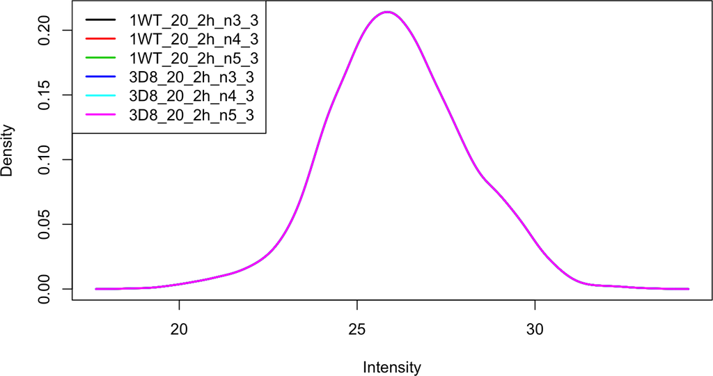

```r
plotDensities(exprs(pepData))
```

We can visualize our data using a Multi Dimensional Scaling plot, eg. as provided by the limma package.

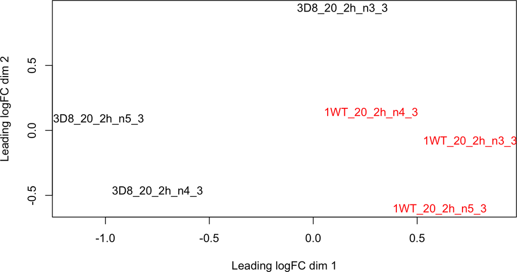

```r
plotMDS(exprs(pepData),col=as.double(pData(pepData)$genotype))
```

## 3.5 Summarization to protein level

```r
protData<-combineFeatures(pepData,fcol="Proteins",method="robust",na.rm=TRUE)
```

```
## Your data contains missing values. Please read the relevant section
## in the combineFeatures manual page for details the effects of
## missing values on data aggregation.
```

If you summarize using robust summarization please refer to Sticker et al. (2019) https://www.biorxiv.org/content/10.1101/668863v1

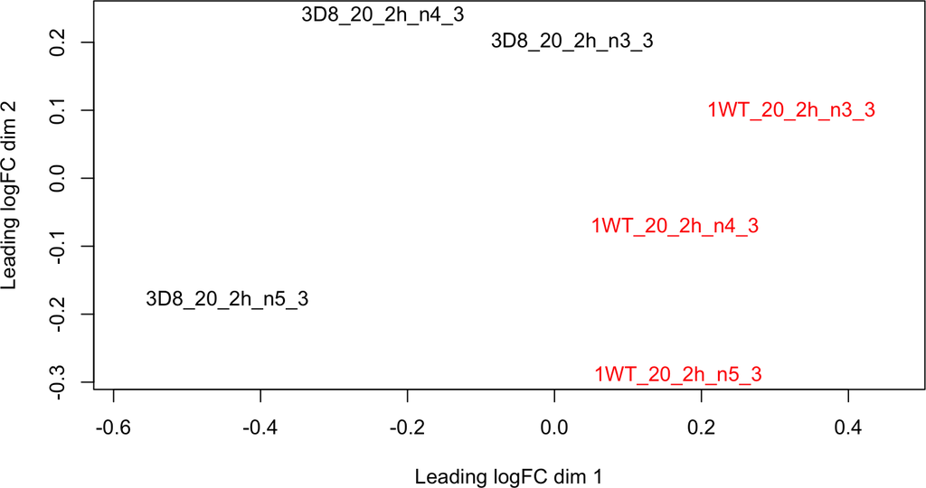

```r
plotMDS(exprs(protData),col=as.double(pData(pepData)$genotype))
```

# 4 Data Analysis

## 4.1 Estimation

MSqRob is currently working with a format where we have one dataframe for each protein. This will be changed in the next release. Therefore we first have to reorganise the data.

Next the models are fitted. This is done using the fit.model function. We only have to model the data using the factor genotype from the pheno data of the protein level MSnSet. The name of the factor variable is specified in the fixed argument (if multiple predictors have to be incorporated in the model, a vector of variable names has to be provided in this argument.). The argument shrinkage is used to specify if ridge regression has to be adopted. For the sake of speed we do not do this in the tutorial. The shrinkage has to be specified for each variable in the fixed effects. We also have to indicate this for the intercept (which we never shrink). So we specify it at c(0,0) to indicate that the intercept (first 0) and the parameters for the factor genotype (second 0) are not penalized. We set the robust_var function equal to FALSE, this functionality will be removed from the package in the next release.

```r
protMSqRob <- MSnSet2protdata(protData, "Proteins")
models <- fit.model(protdata=protMSqRob, response="quant_value", fixed="genotype",shrinkage.fixed=c(0,0),robust_var=FALSE)
```

## 4.2 Inference

Many biologists have problems with the reference coding. In MSqRob we have opted to formulate contrasts using all levels of a factor. Internally, the contrasts are than recasted according to the factor level that is the reference class.

```r
L <- makeContrast("genotypeD8 - genotypeWT",  levels=c("genotypeD8","genotypeWT"))
tests <- test.contrast_adjust(models, L)
nSig <- sum(tests$signif,na.rm=TRUE)
head(tests,nSig)
```

```
##                estimate         se       df       Tval         pval
## WP_003023392 -1.4157255 0.09495236 6.244393 -14.909850 4.072962e-06
## WP_003026016 -1.0438058 0.09752809 6.244393 -10.702617 3.011148e-05
## WP_003040849 -1.2727862 0.12653563 6.244393 -10.058718 4.353920e-05
## WP_003033719 -1.1408207 0.13316912 6.244393  -8.566706 1.117658e-04
## WP_003014552 -0.8972988 0.10749488 6.244393  -8.347363 1.299196e-04
## WP_003034100 -1.3230443 0.16302313 6.244393  -8.115685 1.528741e-04
## WP_003033905 -0.8675023 0.10701943 6.244393  -8.106026 1.539278e-04
## WP_003038350  0.8194242 0.10747039 6.244393   7.624651 2.187353e-04
## WP_003040894 -0.9211707 0.12366201 6.244393  -7.449100 2.497905e-04
## WP_003033046 -0.7528567 0.10373873 6.244393  -7.257239 2.896568e-04
## WP_003014581 -0.9563028 0.11905263 5.244393  -8.032606 3.858971e-04
## WP_003038816 -1.3119995 0.19347379 6.244393  -6.781277 4.242091e-04
## WP_003040790 -1.0514116 0.15747441 6.244393  -6.676714 4.626148e-04
## WP_003040752  0.8487937 0.13378975 6.244393   6.344236 6.138288e-04
## WP_003039713 -0.7316417 0.11754597 6.244393  -6.224302 6.816676e-04
##                     qval signif
## WP_003023392 0.004341778   TRUE
## WP_003026016 0.015470931   TRUE
## WP_003040849 0.015470931   TRUE
## WP_003033719 0.023441000   TRUE
## WP_003014552 0.023441000   TRUE
## WP_003034100 0.023441000   TRUE
## WP_003033905 0.023441000   TRUE
## WP_003038350 0.029146484   TRUE
## WP_003040894 0.029586293   TRUE
## WP_003033046 0.030877411   TRUE
## WP_003014581 0.037396933   TRUE
## WP_003038816 0.037683905   TRUE
## WP_003040790 0.037934411   TRUE
## WP_003040752 0.046738682   TRUE
## WP_003039713 0.048443842   TRUE
```

There are 15 proteins with a significant effect at the 5% FDR level.

## 4.3 Plots

### 4.3.1 Volcano-plot

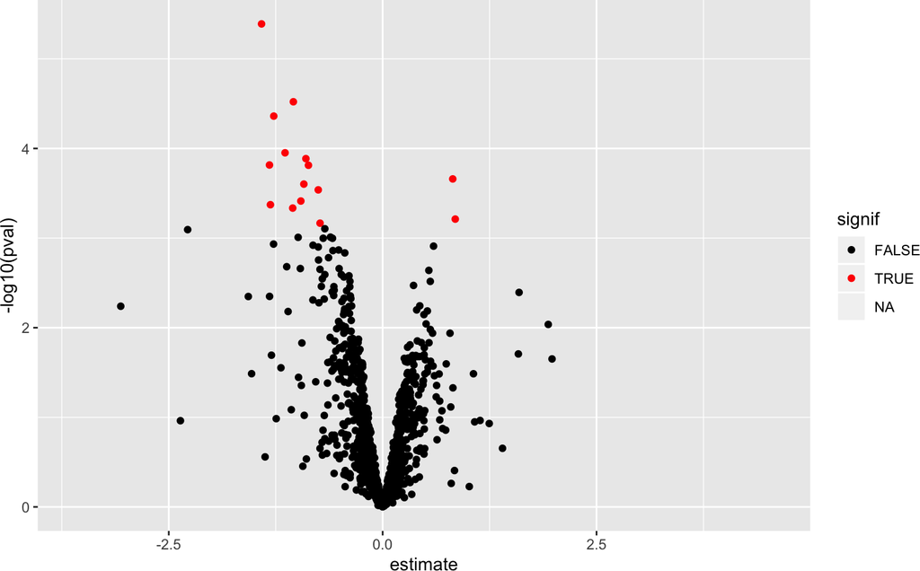

```r
volcano<- ggplot(tests,aes(x=estimate,y=-log10(pval),color=signif)) + geom_point() + scale_color_manual(values=c("black","red"))
volcano
```

An interactive volcano plot can be obtained by using the plotly library. We alter the object tests to add the protein name to the data frame in ggplot, this will allow us to see the protein name in the interactive plot.

```r
library(plotly)
volcano<- ggplot(tests %>% rownames_to_column("protein"),aes(x=estimate,y=-log10(pval),color=signif,protein=protein)) + geom_point() + scale_color_manual(values=c("black","red"))
ggplotly(volcano)
```

### 4.3.2 Heatmap

We first select the names of the significant proteins.

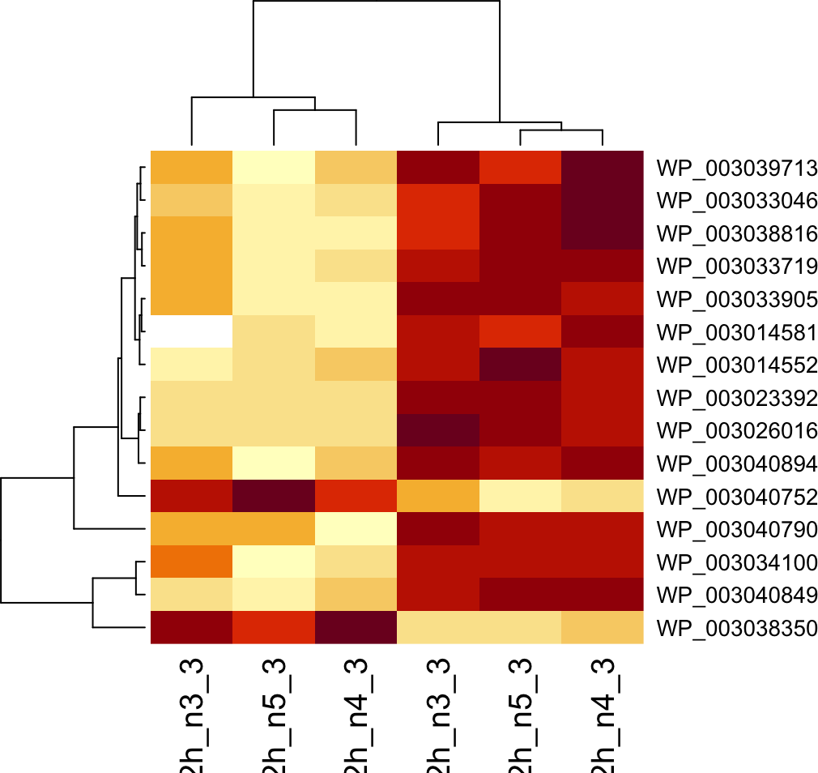

```r
sigNames<- tests %>% rownames_to_column("protein") %>% filter(signif) %>% pull(protein)
heatmap(exprs(protData)[sigNames,])
```

### 4.3.3 Detail plot for the top 5 proteins.

We first extract the normalized protein expression values for a particular protein and we create a dataframe that contains the protein expression values and the relevant variables of the experimental design.

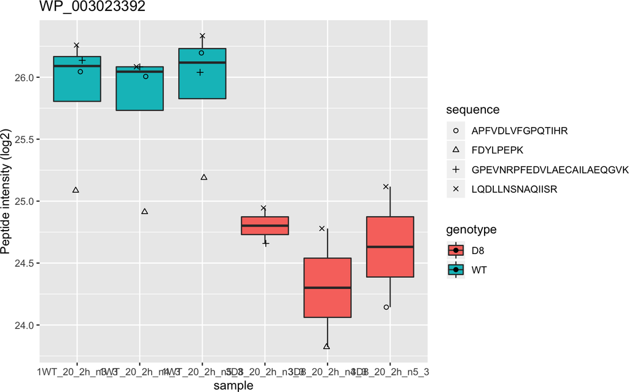

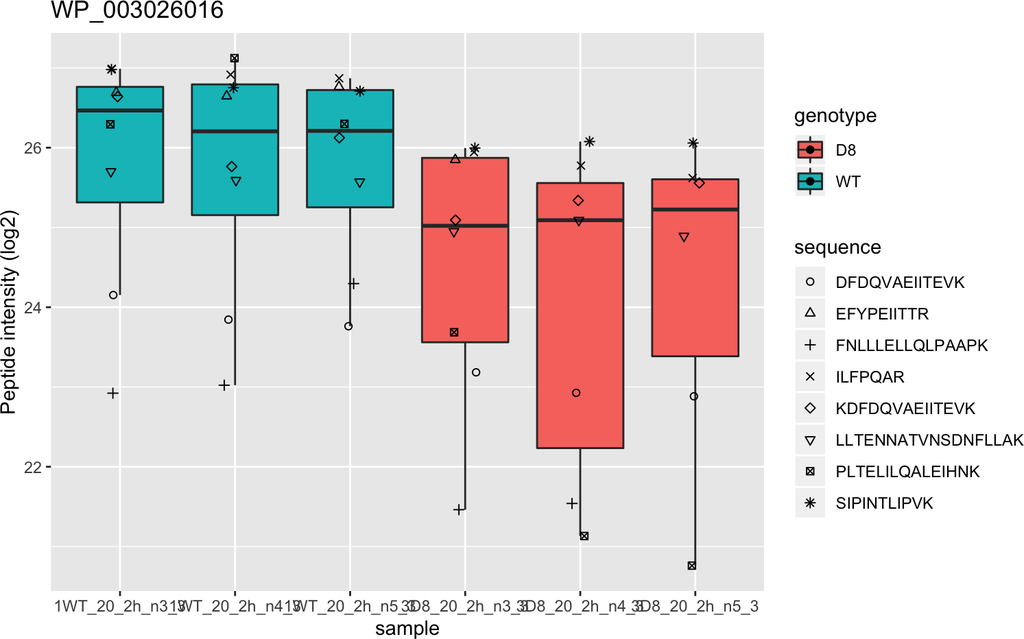

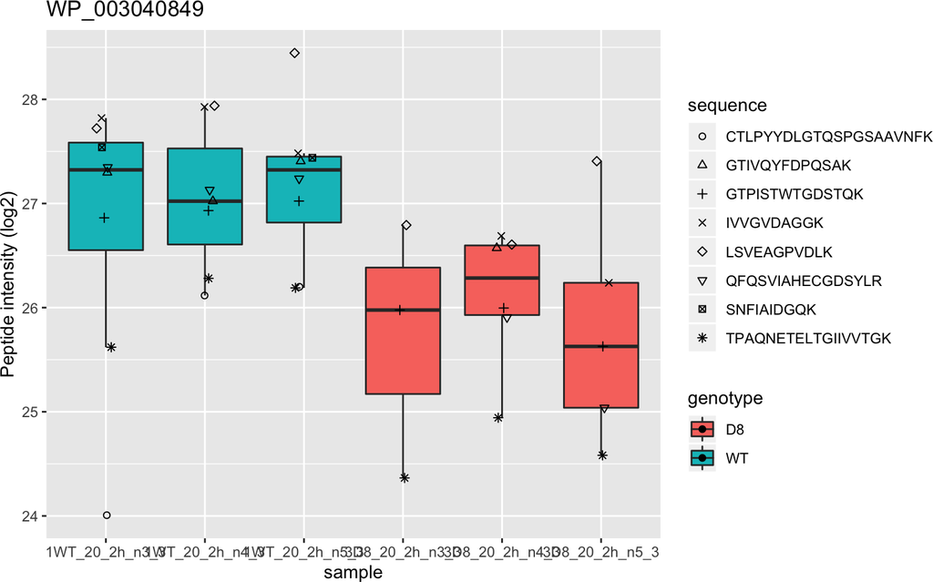

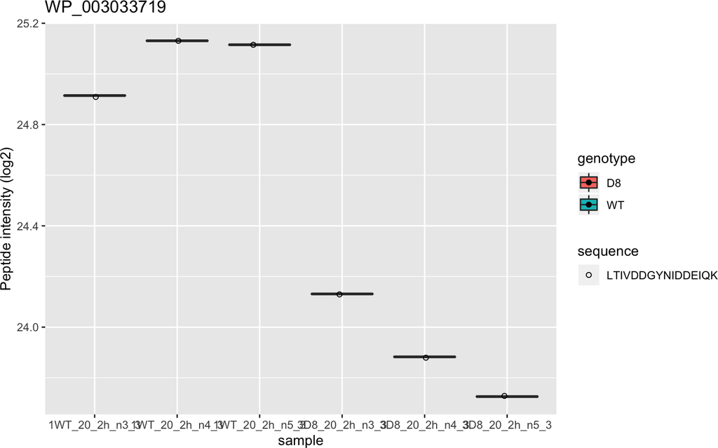

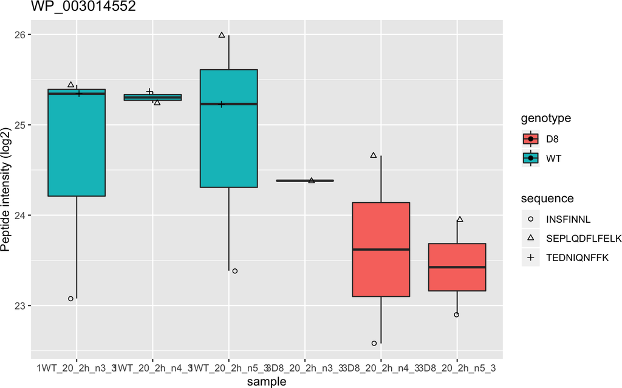

```r
for (protName in rownames(tests)[1:5])
{
plotDat<-pepData[fData(pepData)$Proteins==protName] %>% exprs
plotDataStack<-data.frame(quant_value=c(plotDat),sequence=rep(rownames(plotDat),rep=ncol(plotDat)),sample=rep(colnames(plotDat),each=nrow(plotDat)),genotype=rep(pData(pepData)$genotype,each=nrow(plotDat)))
plot1 <- ggplot(plotDataStack, aes(x=sample, y=quant_value,fill=genotype))
print(plot1 +geom_boxplot(outlier.shape=NA) + geom_point(position=position_jitter(width=.1),aes(shape=sequence)) + scale_shape_manual(values=1:nrow(plotDat)) +labs(title = protName, x="sample", y="Peptide intensity (log2)"))
}
```